# 4-Hour Movie? Frankly, My Dear, I Don’t Give A Damn.

Vivian Wang, Maggie Wang

December 14, 2017

[figure not shown]

Samuel L. Jackson, who is featured in all Quentin Tarantino movies but one, acts out the classic line from *Gone with the Wind*.

It is December 15, 1939 and Loew’s Grand Theatre is shining as center stage for the premiere of American classic, *Gone With The Wind*. Over the next few months, Scarlett and her beloved Rhett will sweep audiences off their feet, shatter attendance records, and garner reverent reviews from magazines and newspapers alike. Amongst the praise, however, are a few grumbles. Some reviewers felt the film was unnecessarily dragged out with repetitious scenes and mundane dialogue upping the minute count. Their claims were not unfounded: *Gone With The Wind clocked* in with a staggering 4-hour runtime, making it the longest American film of its day.

Flash forward to the present, *Gone With The Wind* continues to hold a place amongst the [top 20 longest](http://www.amc.com/talk/2007/11/the-longest-ame-1) American movies ever made. Simultaneously, extended film lengths are again evoking similar ire amongst [millennial moviegoers](http://www.randalolson.com/2014/01/25/movies-arent-actually-much-longer-than-they-used-to-be/) who complain that movies are becoming longer than they used to be. But, have they really gotten longer since the days of black-and-white? Complaining millennials aside, do the rest of us really hate the extra film time?[^1]

As they [battle for profits](http://bgr.com/2015/01/02/netflix-vs-movie-theaters/) with entertainment competitors such as Netflix, production studios and other industry players have high stakes in understanding audience preferences. Luckily, the Internet gives us the means to address these questions with the runtimes and ratings within the [International Movie Database (IMDb)](http://www.imdb.com/). The data reveals not only film length patterns that reflect the history of entertainment technology, but also that we take a page from Rhett when it comes to enjoying long movies: frankly, we don’t give a damn.

```r
# Pull information all at once from server via sql query
# Limited to films more than 60mins long, produced in the US, and not adult

ratelength_sql <- "
SELECT t.id, t.title,
    t.production_year AS Year,
  mii.info AS Rating,
  mi.info AS Length,
  mii2.info AS Votes,
  n.name AS Director
FROM title t
JOIN movie_info_idx mii ON mii.movie_id = t.id
JOIN movie_info mi ON mi.movie_id = t.id
JOIN movie_info_idx mii2 ON mii2.movie_id = t.id
JOIN movie_info mi2 ON mi2.movie_id = t.id
JOIN movie_info mi3 ON mi3.movie_id = t.id
JOIN cast_info ci ON ci.movie_id = t.id
JOIN name n ON n.id = ci.person_id
WHERE t.kind_id = 1
AND mii.info_type_id = 101
AND mi.info_type_id = 1
AND mi.info > 59
AND mii2.info_type_id = 100
AND mii2.info > 1000
AND mi2.info_type_id = 3
AND mi2.info NOT LIKE '%Adult%'
AND mi3.info_type_id = 8
AND mi3.info LIKE '%USA%'
AND ci.role_id = 8
GROUP BY t.id;
"

ratelength <- db %>%
  dbGetQuery(ratelength_sql) %>%
  mutate(Length = as.integer(Length)) %>%
  mutate(Rating = as.numeric (Rating)) %>%
  mutate(Votes = as.integer(Votes)) %>%
  mutate(Director = format_reverse(Director))

# Manually correct The Hateful Eight data
ratelength$Length[ratelength$title == "The Hateful Eight"] <- as.integer(187)
```

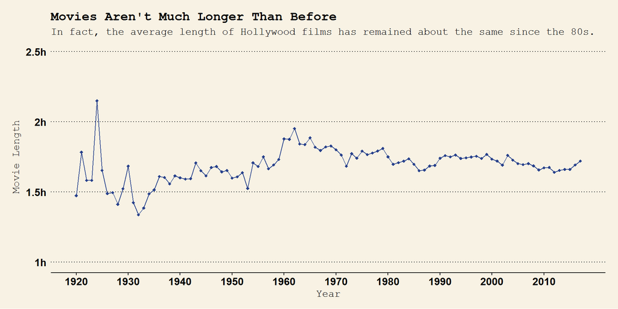

```r
# Find average film length over the years
avg_length <- ratelength %>%
  group_by(Year) %>%
  summarize(Length = mean(Length))

# Plot average length against year of film release
avg_length %>% ggplot(aes(x = Year, y = Length)) +
  geom_point(shape = 18, color = "royalblue4") +
  geom_line(color = "royalblue4") +
  theme_wsj() +
  theme(axis.title = element_text(size = 12),
        plot.title = element_text(size = 15),
        plot.subtitle = element_text(size = 12)) +
  scale_x_continuous(limits = c(1920, 2017),
                     breaks = c(1920, 1930, 1940, 1950, 1960, 1970, 1980, 1990, 2000, 2010)) +
  scale_y_continuous(name = "Movie Length", limits = c(60,150),
                     breaks = c(60, 90, 120, 150),
                     labels = c("1h", "1.5h", "2h", "2.5h")) +
  labs(title = "Movies Aren't Much Longer Than Before",
       subtitle = "In fact, the average length of Hollywood films has remained about the same since the 80s.")
```

The first task is demystifying the accusations around increasing movie length here in the U.S. In graphic above, the length of all the movies released in each year are averaged out and displayed against a time scale running from the glamourous 1920s to modern Hollywood. Besides the uptick around 1925 when the [Golden Age of Hollywood](http://www.filmsite.org/20sintro.html) popularized long feature films, average film length seems to have remained between 1.5 and 2 hours throughout the years. In other words, movie lengths haven’t been significantly extended over the decades.

So do millennials lose this match point? Not quite. Though Graphic 1 shows average length staying within 1.5 to 2 hours, there are clearly ups-and-downs from decade to decade. When the [millennial generation](https://www.huffingtonpost.com/christine-henseler/millennials-and-boomers-generation-x_b_5253931.html) (born 1985-2000) was filling theater seats, runtime averages were indeed on the rise. From their perspective, they aren’t wrong in arguing that movies have gotten longer. Conversely, to you [Generation Xers](https://www.huffingtonpost.com/christine-henseler/millennials-and-boomers-generation-x_b_5253931.html) (born 1965-1985) insisting millennials whine too much, Graphic 1 provides a reminder that the victory of and adherence to 2-hour VHS tapes in the [videotape format war](https://en.wikipedia.org/wiki/Videotape_format_war) of the 70s slashed an average of 10 minutes off your childhood movies. There’s no clear winner here; we’re all justified.

The period from 1930 to 1960 also exhibits an upward trend peaking around 1960 at 2 hours. The [rise of television](http://www.encyclopedia.com/arts/culture-magazines/hollywood-and-television-1950s-roots-diversification) in the 30s through 60s forced movie producers to compete by releasing epic films that extended runtimes by an average of around 30 minutes. Nowadays, TV and online streaming don’t appear to threaten movie studios as much as it used to. From 2000 onwards, runtimes stagnated at around 1.7 hours.

Then are we really whining about long movies? Recall the last time you sat through a 3 hour movie - did you walk out complaining about having to pee or about how tedious the film was? Data shows that your hours of suffering waslikely worth it - longer films are actually rated higher.

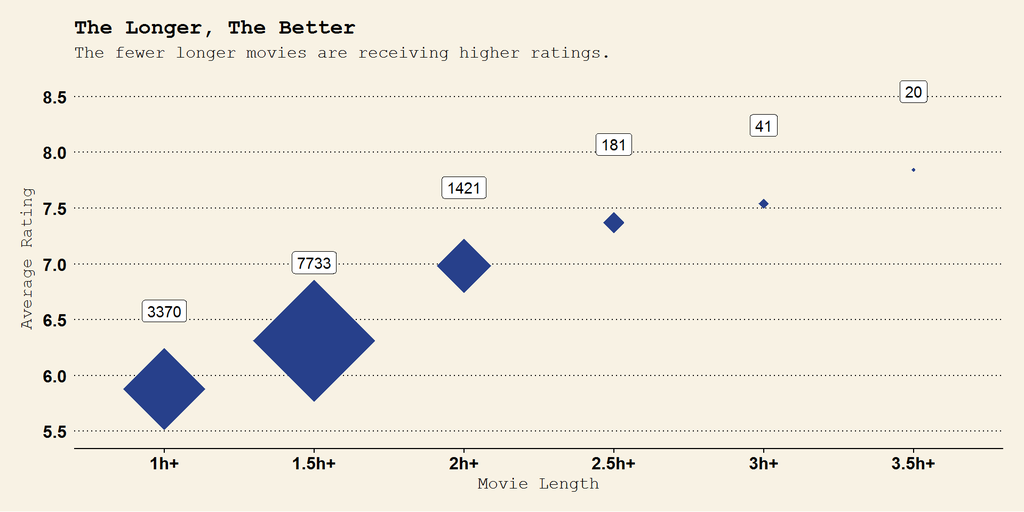

```r
# Bin film length, find count and average rating
avg_rating_length <- ratelength %>%
  mutate(Length = cut(ratelength$Length,
                      breaks = c(-Inf, 90, 120, 150, 180, 210, Inf),
                      labels = c("1h+", "1.5h+", "2h+", "2.5h+", "3h+", "3.5h+"),
                      include.lowest = TRUE)) %>%
  group_by(Length) %>%
  summarize(num = n(), Rating = mean(Rating))

# Plot rating against length
# Size of diamond indicate number of films in the bin
avg_rating_length %>%
  ggplot(aes(x = Length, y = Rating)) +
  geom_point(aes(size = num), shape = 18,
             color = "royalblue4") +
  geom_label(aes(label = num), nudge_y = .7) +
  theme_wsj() +
  scale_size(range = c(1,40)) +
  theme(legend.position = "none") +
  theme(axis.title = element_text(size = 12),
        plot.title = element_text(size = 15),
        plot.subtitle = element_text(size = 12)) +
  scale_x_discrete(name = "Movie Length") +
  scale_y_continuous(name = "Average Rating",
                     limits = c(5.5, 8.6),
                     breaks = c(-Inf, 5.5, 6.0, 6.5, 7.0, 7.5, 8.0, 8.5, Inf)) +
  labs(title = "The Longer, The Better",
       subtitle = "The fewer longer movies are receiving higher ratings.")
```

One possible explanation for this phenomenon stems from directors and their reputations for producing standout films. When a new director hits the scene, they have little credibility. Business-savvy production studios and investors are unlikely to trust newbies who haven’t proven their commercial appeal with extensive budgets. Without backing, longer movies are financially unattainable. Pulling in profits wins directors higher budgets, expansive resources, and creative freedom to produce longer movies. Whether those dollars are brought in by visionary talent or ability to capitalize on shock value, their presence indicates audience approval and higher ratings. Longer movies land higher ratings because only directors who have shown that they can attract audiences are trusted to produce them.

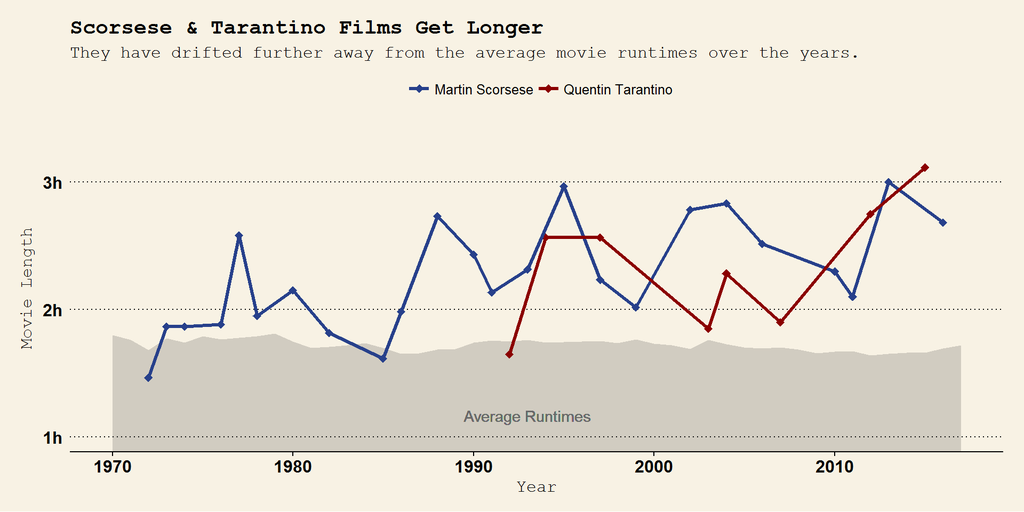

```r
# Big directors and film length
bignames <- ratelength %>%
  select(-id, -Rating) %>%
  filter(Director %in%
           c('Martin Scorsese','Quentin Tarantino')) %>%
  filter(Votes >= 5000)

bignames_plot <- avg_length %>%
  ggplot(aes(x = Year, y = Length)) +
  geom_area(stat = "identity", alpha = 0.2) +
  geom_text(data = NULL, aes(x = 1993, y = 70),
            label = "Average Runtimes", color = "dimgray") +
  theme_wsj() +
  theme(axis.title = element_text(size = 12),
        legend.title = element_blank(),
        plot.title = element_text(size = 15),
        plot.subtitle = element_text(size = 12)) +
  scale_x_continuous(name = "Year", limits = c(1970, 2017)) +
  scale_y_continuous(name = "Movie Length",
                     breaks = c(-Inf, 60, 120, 180, Inf),
                     labels = c('1h-', '1h', '2h', '3h', '3h+')) +
  coord_cartesian(ylim = c(60, 200)) +
  geom_point(data = bignames, aes(color = bignames$Director), shape = 18, size = 2.5) +
  geom_line(data = bignames, aes(color = bignames$Director), size = 1.2) +
  scale_color_manual(values = c("RoyalBlue4", "darkred")) +
  labs(title = "Scorsese & Tarantino Films Get Longer",
       subtitle = "They have drifted further away from the average movie runtimes over the years.")

bignames_plot
```

```r
# Find information about films longer than 3h
genre_long <- ratelength %>%
  filter(Length >= 180)

# Show information of long films, sorted by rating
genre_long %>%
  select(Rating, title, Year, Length, Votes, Director) %>%
  filter(title != "Kill Bill: The Whole Bloody Affair") %>%
  rename('Film' = 'title') %>%
  arrange(desc(Rating), desc(Votes)) %>%
  kable(format = "html", align = 'c',
        caption = "Ratings of Movies Longer Than 3 Hours") %>%
  kable_styling("striped") %>%
  scroll_box(height = "440px")
```

Ratings of Movies Longer Than 3 Hours

| Rating | Film | Year | Length | Votes | Director |
| --- | --- | --- | --- | --- | --- |
| 9.0 | The Godfather: Part II | 1974 | 202 | 879985 | Francis Ford Coppola |
| 9.0 | O.J.: Made in America | 2016 | 467 | 12067 | Ezra Edelman |
| 8.9 | The Lord of the Rings: The Return of the King | 2003 | 263 | 1337090 | Peter Jackson |
| 8.9 | Schindler’s List | 1993 | 195 | 960594 | Steven Spielberg |
| 8.7 | The Lord of the Rings: The Two Towers | 2002 | 235 | 1210758 | Peter Jackson |
| 8.5 | The Green Mile | 1999 | 189 | 884373 | Frank Darabont |
| 8.4 | Once Upon a Time in America | 1984 | 229 | 244974 | Sergio Leone |
| 8.3 | Lawrence of Arabia | 1962 | 216 | 213605 | David Lean |
| 8.3 | Judgment at Nuremberg | 1961 | 186 | 51053 | Stanley Kramer |
| 8.3 | Il mio viaggio in Italia | 1999 | 246 | 2560 | Martin Scorsese |
| 8.3 | Unforgivable Blackness: The Rise and Fall of Jack Johnson | 2004 | 214 | 1112 | Ken Burns |
| 8.2 | The Wolf of Wall Street | 2013 | 180 | 900450 | Martin Scorsese |
| 8.2 | The Deer Hunter | 1978 | 183 | 255418 | Michael Cimino |
| 8.2 | Gone with the Wind | 1939 | 226 | 236402 | George Cukor |
| 8.1 | Gandhi | 1982 | 191 | 188060 | Richard Attenborough |
| 8.1 | Ben-Hur | 1959 | 212 | 179027 | William Wyler |
| 8.1 | Barry Lyndon | 1975 | 184 | 113358 | Stanley Kubrick |
| 8.1 | Woodstock | 1970 | 184 | 13608 | Michael Wadleigh |
| 8.0 | Magnolia | 1999 | 188 | 254372 | Paul Thomas Anderson |
| 8.0 | Dances with Wolves | 1990 | 181 | 201820 | Kevin Costner |
| 8.0 | JFK | 1991 | 189 | 121967 | Oliver Stone |
| 8.0 | Doctor Zhivago | 1965 | 197 | 59514 | David Lean |
| 8.0 | Fiddler on the Roof | 1971 | 181 | 32028 | Norman Jewison |
| 8.0 | Kagemusha | 1980 | 180 | 25781 | Akira Kurosawa |
| 8.0 | Bound by Honor | 1993 | 180 | 24752 | Taylor Hackford |
| 7.9 | Spartacus | 1960 | 184 | 105086 | Stanley Kubrick |
| 7.9 | The Ten Commandments | 1956 | 220 | 52080 | Cecil B. DeMille |
| 7.9 | The Right Stuff | 1983 | 193 | 48243 | Philip Kaufman |
| 7.9 | Adolf Hitler: The Greatest Story Never Told | 2013 | 350 | 3379 | Dennis Wise |
| 7.8 | Titanic | 1997 | 194 | 865579 | James Cameron |
| 7.8 | The Hateful Eight | 2015 | 187 | 363199 | Quentin Tarantino |
| 7.8 | Hamlet | 1996 | 242 | 32159 | Kenneth Branagh |
| 7.8 | A Star Is Born | 1954 | 181 | 11497 | George Cukor |
| 7.7 | Malcolm X | 1992 | 202 | 69299 | Spike Lee |
| 7.7 | Short Cuts | 1993 | 188 | 37236 | Robert Altman |
| 7.7 | Giant | 1956 | 201 | 28442 | George Stevens |
| 7.7 | Gettysburg | 1993 | 271 | 23014 | Ron Maxwell |
| 7.7 | The Sand Pebbles | 1966 | 182 | 11058 | Robert Wise |
| 7.6 | Grindhouse | 2007 | 191 | 162721 | Robert Rodriguez |
| 7.6 | It’s a Mad Mad Mad Mad World | 1963 | 182 | 31647 | Stanley Kramer |
| 7.5 | Reds | 1981 | 195 | 17599 | Warren Beatty |
| 7.4 | The Diary of Anne Frank | 1959 | 180 | 10107 | George Stevens |
| 7.4 | The Iceman Cometh | 1973 | 239 | 1137 | John Frankenheimer |
| 7.3 | El Cid | 1961 | 182 | 10617 | Anthony Mann |
| 7.3 | Nicholas and Alexandra | 1971 | 183 | 3626 | Franklin J. Schaffner |
| 7.3 | Flash Gordon | 1936 | 245 | 1724 | Frederick Stephani |
| 7.3 | National Gallery | 2014 | 180 | 1016 | Frederick Wiseman |
| 7.2 | King Kong | 2005 | 200 | 341817 | Peter Jackson |
| 7.2 | Cremaster 3 | 2002 | 182 | 1235 | Matthew Barney |
| 7.1 | Nixon | 1995 | 192 | 25479 | Oliver Stone |
| 7.0 | Inland Empire | 2006 | 180 | 45762 | David Lynch |
| 7.0 | Cleopatra | 1963 | 192 | 23838 | Joseph L. Mankiewicz |
| 6.8 | Exodus | 1960 | 208 | 7445 | Otto Preminger |
| 6.8 | War and Peace | 1956 | 208 | 7421 | King Vidor |
| 6.8 | Bis ans Ende der Welt | 1991 | 280 | 7377 | Wim Wenders |
| 6.8 | At Play in the Fields of the Lord | 1991 | 189 | 2761 | Hector Babenco |
| 6.7 | Wyatt Earp | 1994 | 191 | 38231 | Lawrence Kasdan |
| 6.7 | The Birth of a Nation | 1915 | 190 | 18568 | D.W. Griffith |
| 6.7 | The Fall of the Roman Empire | 1964 | 188 | 6740 | Anthony Mann |
| 6.6 | The Greatest Story Ever Told | 1965 | 199 | 7041 | David Lean |
| 6.6 | Hawaii | 1966 | 189 | 2225 | George Roy Hill |
| 6.5 | Batman | 1943 | 260 | 1489 | Lambert Hillyer |
| 6.4 | Raintree County | 1957 | 188 | 2831 | Edward Dmytryk |
| 6.3 | Gods and Generals | 2003 | 219 | 13857 | Ron Maxwell |
| 6.3 | Batman and Robin | 1949 | 263 | 1315 | Spencer Gordon Bennet |
| 6.1 | Pearl Harbor | 2001 | 183 | 273038 | Michael Bay |

So, long story short: Even if that next *Star Wars* franchise is 4 hours long, we’ll still be happily glued to our seats and devotedly chanting “May the Force Be With You” all the way through.

[^1]: For more information about our study, please refer to our [GitHub repository](https://github.com/wxiaonanw/sds192-mp4-vivian-maggie).